# COD_20230301_HOST_1_QC_analysis

# A7. LM of function alpha diversity

```
--> both stratified and nonstratified
```

```r
sample_data <- sample_data(phyloseq$phyloseq_path_rpkm) %>% data.frame(check.names = F) %>% subset(., !is.nan(.$simpson))

cat("Species richness of all samples\n\n")
```

```
## Species richness of all samples
```

```r
cat("S.obs ~ sample_type * treatment + log10 (Final_reads) + (1|original_sample)\n\n")
```

[output not shown]

```r
lmer(S.obs ~ sample_type * treatment + log10 (Final_reads) + (1|subject_id), data = sample_data) %>%
        summary() %>%
        .$coefficients %>%
        data.frame(check.names = F) %>%
        mutate(` ` = case_when(abs(`Pr(>|t|)`) < 0.05 ~ "*",
                               .default = " ")) %>%
        kbl(format = "html") %>%
        kable_styling(full_width = 0, html_font = "serif")
```

Estimate

Std. Error

df

t value

Pr(>|t|)

(Intercept)

-271.32533

63.94609

72.47916

-4.2430322

0.0000643

sample_typeNasal swab

66.71179

39.44578

32.64336

1.6912273

0.1003209

sample_typeSputum

142.80087

36.31835

41.80438

3.9319203

0.0003111

treatmentlyPMA

59.31768

31.18858

64.39962

1.9019036

0.0616583

treatmentBenzonase

96.59262

31.65626

66.97650

3.0512965

0.0032643

treatmentHost zero

129.84121

32.25492

67.36194

4.0254694

0.0001466

treatmentMolysis

150.32258

32.65321

67.58822

4.6036081

0.0000189

treatmentQIAamp

86.27368

32.71224

67.61999

2.6373516

0.0103578

log10(Final_reads)

52.77944

11.01007

70.54314

4.7937427

0.0000088

sample_typeNasal swab:treatmentlyPMA

-23.81209

39.44179

64.87664

-0.6037273

0.5481301

sample_typeSputum:treatmentlyPMA

-5.02253

39.40167

62.83470

-0.1274700

0.8989755

sample_typeNasal swab:treatmentBenzonase

-80.25929

38.01990

65.40988

-2.1109811

0.0386006

sample_typeSputum:treatmentBenzonase

-52.43718

38.65224

63.57018

-1.3566400

0.1796940

sample_typeNasal swab:treatmentHost zero

-106.90271

36.81521

64.23327

-2.9037647

0.0050492

sample_typeSputum:treatmentHost zero

-76.35866

38.92443

62.75019

-1.9617158

0.0542352

sample_typeNasal swab:treatmentMolysis

-106.97855

38.54815

66.00383

-2.7751931

0.0071693

sample_typeSputum:treatmentMolysis

-108.15918

39.34418

62.63915

-2.7490513

0.0077999

sample_typeNasal swab:treatmentQIAamp

-75.62038

36.68939

64.06591

-2.0610968

0.0433576

sample_typeSputum:treatmentQIAamp

-40.59820

38.59881

63.08680

-1.0517993

0.2969039

```r
#Species richness  - stratified
cat("Species richness at NS\n\n")
```

```
## Species richness at NS
```

```r
cat("S.obs ~ sample_type + log10 (Final_reads) + (1|original_sample)\n\n")
```

[output not shown]

```r
lmer(S.obs ~ treatment + log10 (Final_reads) + (1|subject_id), data = subset(sample_data, sample_data$sample_type == "Nasal swab")) %>%
        summary() %>%
        .$coefficients %>%
        data.frame(check.names = F) %>%
        mutate(` ` = case_when(abs(`Pr(>|t|)`) < 0.05 ~ "*",
                               .default = " ")) %>%
        kbl(format = "html") %>%
        kable_styling(full_width = 0, html_font = "serif")
```

Estimate

Std. Error

df

t value

Pr(>|t|)

(Intercept)

68.35891

68.76371

28

0.9941131

0.3286817

treatmentlyPMA

13.88909

17.11543

28

0.8114955

0.4239262

treatmentBenzonase

20.95703

16.24183

28

1.2903126

0.2074965

treatmentHost zero

56.43052

18.37320

28

3.0713495

0.0047048

treatmentMolysis

51.56131

16.32822

28

3.1578029

0.0037880

treatmentQIAamp

54.41631

19.71859

28

2.7596444

0.0100871

log10(Final_reads)

12.25116

10.45340

28

1.1719787

0.2510816

```r
cat("Species richness at BAL\n\n")
```

```
## Species richness at BAL
```

```r
cat("S.obs ~ sample_type + log10 (Final_reads) + (1|original_sample)\n\n")
```

[output not shown]

```r
lmer(S.obs ~ treatment + log10 (Final_reads) + (1|original_sample), data = subset(sample_data, sample_data$sample_type == "BAL")) %>%
        summary() %>%
        .$coefficients %>%
        data.frame(check.names = F) %>%
        mutate(` ` = case_when(abs(`Pr(>|t|)`) < 0.05 ~ "*",
                               .default = " ")) %>%
        kbl(format = "html") %>%
        kable_styling(full_width = 0, html_font = "serif")
```

Estimate

Std. Error

df

t value

Pr(>|t|)

(Intercept)

-640.83129

99.14027

19.00295

-6.4638848

0.0000034

treatmentlyPMA

14.46191

33.76511

18.36963

0.4283092

0.6734060

treatmentBenzonase

16.49562

35.65062

19.98741

0.4627021

0.6485757

treatmentHost zero

39.81066

36.93641

19.98154

1.0778162

0.2939563

treatmentMolysis

54.18626

37.78713

19.92262

1.4339874

0.1670859

treatmentQIAamp

-10.73947

37.91284

19.91125

-0.2832674

0.7798961

log10(Final_reads)

124.09731

17.94627

17.34430

6.9149360

0.0000022

```r
cat("Species richness at sputum\n\n")
```

```
## Species richness at sputum
```

```r
cat("S.obs ~ sample_type + log10 (Final_reads) + (1|original_sample)\n\n")
```

[output not shown]

```r
lmer(S.obs ~ treatment + log10 (Final_reads) + (1|original_sample), data = subset(sample_data, sample_data$sample_type == "Sputum")) %>%
        summary() %>%
        .$coefficients %>%
        data.frame(check.names = F) %>%
        mutate(` ` = case_when(abs(`Pr(>|t|)`) < 0.05 ~ "*",
                               .default = " ")) %>%
        kbl(format = "html") %>%
        kable_styling(full_width = 0, html_font = "serif")
```

|  | Estimate | Std. Error | df | t value | Pr(>\|t\|) |  |
| --- | --- | --- | --- | --- | --- | --- |
| (Intercept) | -127.58303 | 198.98655 | 21.38568 | -0.6411641 | 0.5282282 |  |
| treatmentlyPMA | 54.38241 | 28.77622 | 19.88708 | 1.8898385 | 0.0734460 |  |
| treatmentBenzonase | 44.29211 | 36.29072 | 20.41549 | 1.2204804 | 0.2361930 |  |
| treatmentHost zero | 53.75292 | 61.00733 | 20.95720 | 0.8810895 | 0.3882627 |  |
| treatmentMolysis | 42.48496 | 71.13867 | 21.03201 | 0.5972132 | 0.5567405 |  |
| treatmentQIAamp | 45.90423 | 52.95334 | 20.86328 | 0.8668807 | 0.3958683 |  |
| log10(Final_reads) | 52.61786 | 33.96577 | 21.23460 | 1.5491436 | 0.1361234 |  |

```r
#Shannon
cat("Shannon index\n\n")
```

```
## Shannon index
```

```r
cat("Shannon ~ sample_type + log10 (Final_reads) + (1|original_sample)\n\n")
```

```
## Shannon ~ sample_type + log10 (Final_reads) + (1|original_sample)
```

```r
lmer(data_shannon ~ sample_type * treatment + log10 (Final_reads) + (1|original_sample), data = sample_data) %>%
        summary() %>%
        .$coefficients %>%
        data.frame(check.names = F) %>%
        mutate(` ` = case_when(abs(`Pr(>|t|)`) < 0.05 ~ "*",
                               .default = " ")) %>%
        kbl(format = "html") %>%
        kable_styling(full_width = 0, html_font = "serif")
```

Estimate

Std. Error

df

t value

Pr(>|t|)

(Intercept)

0.6277442

0.1923582

72.90417

3.2634128

0.0016771

sample_typeNasal swab

0.3782276

0.0948640

66.24283

3.9870501

0.0001694

sample_typeSputum

0.3038993

0.0968430

65.80070

3.1380607

0.0025449

treatmentlyPMA

0.2080648

0.0912575

59.31888

2.2799751

0.0262196

treatmentBenzonase

0.1074536

0.0924809

65.10258

1.1619011

0.2495177

treatmentHost zero

0.2663135

0.0943090

66.22861

2.8238390

0.0062621

treatmentMolysis

0.3493594

0.0955289

66.88889

3.6571063

0.0005034

treatmentQIAamp

0.0974529

0.0957099

66.98134

1.0182112

0.3122414

log10(Final_reads)

-0.0167122

0.0335618

71.90795

-0.4979546

0.6200356

sample_typeNasal swab:treatmentlyPMA

-0.2199998

0.1167864

63.60638

-1.8837795

0.0641674

sample_typeSputum:treatmentlyPMA

-0.0942524

0.1154524

55.89187

-0.8163741

0.4177521

sample_typeNasal swab:treatmentBenzonase

-0.0695042

0.1120531

63.47768

-0.6202792

0.5372946

sample_typeSputum:treatmentBenzonase

0.0023288

0.1130661

57.07248

0.0205967

0.9836392

sample_typeNasal swab:treatmentHost zero

-0.2682060

0.1085902

60.90331

-2.4698926

0.0163329

sample_typeSputum:treatmentHost zero

-0.2089075

0.1142346

56.03885

-1.8287583

0.0727592

sample_typeNasal swab:treatmentMolysis

-0.3849402

0.1134802

64.38350

-3.3921345

0.0011901

sample_typeSputum:treatmentMolysis

-0.2757981

0.1156639

56.27671

-2.3844786

0.0204979

sample_typeNasal swab:treatmentQIAamp

-0.1846564

0.1083181

60.79440

-1.7047607

0.0933449

sample_typeSputum:treatmentQIAamp

-0.0636306

0.1130449

56.24157

-0.5628795

0.5757540

```r
#Simpson
cat("Inverse Simpson index\n\n")
```

```
## Inverse Simpson index
```

```r
cat("InvSimp ~ sample_type + log10 (Final_reads) + (1|original_sample)\n\n")
```

```
## InvSimp ~ sample_type + log10 (Final_reads) + (1|original_sample)
```

```r
lmer(data_invsimpson ~ sample_type * treatment + log10 (Final_reads) + (1|original_sample), data = sample_data) %>%
        summary() %>%
        .$coefficients %>%
        data.frame(check.names = F) %>%
        mutate(` ` = case_when(abs(`Pr(>|t|)`) < 0.05 ~ "*",
                               .default = " ")) %>%
        kbl(format = "html") %>%
        kable_styling(full_width = 0, html_font = "serif")
```

Estimate

Std. Error

df

t value

Pr(>|t|)

(Intercept)

2.5338586

0.3135385

70.96294

8.0814913

0.0000000

sample_typeNasal swab

0.2842938

0.1520494

68.03030

1.8697465

0.0658228

sample_typeSputum

0.3782501

0.1558509

70.95435

2.4270003

0.0177657

treatmentlyPMA

0.3397324

0.1563898

61.65671

2.1723442

0.0336834

treatmentBenzonase

0.0472378

0.1563836

68.23317

0.3020637

0.7635223

treatmentHost zero

0.2329645

0.1590151

69.37014

1.4650462

0.1474261

treatmentMolysis

0.3567617

0.1607861

70.00663

2.2188598

0.0297400

treatmentQIAamp

0.0582910

0.1610497

70.09361

0.3619443

0.7184825

log10(Final_reads)

-0.1644187

0.0540196

64.44675

-3.0436866

0.0033807

sample_typeNasal swab:treatmentlyPMA

-0.4423346

0.1983466

65.97618

-2.2301099

0.0291475

sample_typeSputum:treatmentlyPMA

-0.3759508

0.1993215

57.44567

-1.8861530

0.0643330

sample_typeNasal swab:treatmentBenzonase

-0.0381545

0.1903215

66.04230

-0.2004738

0.8417261

sample_typeSputum:treatmentBenzonase

-0.1934003

0.1947030

58.93845

-0.9933096

0.3246198

sample_typeNasal swab:treatmentHost zero

-0.3256749

0.1855479

62.96653

-1.7552062

0.0840880

sample_typeSputum:treatmentHost zero

-0.4518719

0.1971485

57.67798

-2.2920381

0.0255722

sample_typeNasal swab:treatmentMolysis

-0.5649464

0.1923302

67.03548

-2.9373781

0.0045336

sample_typeSputum:treatmentMolysis

-0.5317988

0.1995233

57.91638

-2.6653467

0.0099491

sample_typeNasal swab:treatmentQIAamp

-0.1812611

0.1851750

62.57751

-0.9788638

0.3314165

sample_typeSputum:treatmentQIAamp

-0.3137393

0.1950063

57.95487

-1.6088678

0.1130797

```r
#BPI
cat("Beger Parker index\n\n")
```

```
## Beger Parker index
```

```r
cat("BPI ~ sample_type + log10 (Final_reads) + (1|original_sample)\n\n")
```

```
## BPI ~ sample_type + log10 (Final_reads) + (1|original_sample)
```

```r
lmer(dbp ~ sample_type * treatment + log10 (Final_reads) + (1|original_sample), data = sample_data) %>%
        summary() %>%
        .$coefficients %>%
        data.frame(check.names = F) %>%
        mutate(` ` = case_when(abs(`Pr(>|t|)`) < 0.05 ~ "*",
                               .default = " ")) %>%
        kbl(format = "html") %>%
        kable_styling(full_width = 0, html_font = "serif")
```

Estimate

Std. Error

df

t value

Pr(>|t|)

(Intercept)

0.3440391

0.1258762

70.13993

2.7331535

0.0079332

sample_typeNasal swab

-0.0940641

0.0609175

68.34780

-1.5441228

0.1271764

sample_typeSputum

-0.1495148

0.0626267

71.73071

-2.3873954

0.0196055

treatmentlyPMA

-0.1360672

0.0637784

62.70891

-2.1334365

0.0368082

treatmentBenzonase

-0.0137189

0.0634994

69.15451

-0.2160472

0.8295870

treatmentHost zero

-0.0775264

0.0645073

70.21212

-1.2018236

0.2334698

treatmentMolysis

-0.1514704

0.0651879

70.79134

-2.3235979

0.0230235

treatmentQIAamp

-0.0147607

0.0652893

70.86956

-0.2260821

0.8217883

log10(Final_reads)

0.0701153

0.0215697

61.84125

3.2506433

0.0018652

sample_typeNasal swab:treatmentlyPMA

0.1871812

0.0806756

66.80034

2.3201722

0.0233951

sample_typeSputum:treatmentlyPMA

0.1784389

0.0814836

58.41893

2.1898742

0.0325394

sample_typeNasal swab:treatmentBenzonase

0.0181788

0.0774064

66.92125

0.2348489

0.8150431

sample_typeSputum:treatmentBenzonase

0.0966450

0.0795283

59.95203

1.2152280

0.2290433

sample_typeNasal swab:treatmentHost zero

0.1112523

0.0756141

63.85620

1.4713183

0.1461162

sample_typeSputum:treatmentHost zero

0.1766839

0.0805844

58.67215

2.1925319

0.0323198

sample_typeNasal swab:treatmentMolysis

0.2327702

0.0781693

67.88223

2.9777684

0.0040230

sample_typeSputum:treatmentMolysis

0.2309710

0.0815446

58.89704

2.8324495

0.0063138

sample_typeNasal swab:treatmentQIAamp

0.0548290

0.0754814

63.39830

0.7263905

0.4702729

sample_typeSputum:treatmentQIAamp

0.1291496

0.0796962

58.96349

1.6205246

0.1104560

# A8. permanova of function beta diversity

```
--> both stratified and nonstratified
```

```r
phyloseq_rel_nz <- subset_samples(phyloseq$phyloseq_path_rpkm, S.obs != 0 & sample_type %in% c("BAL", "Nasal swab", "Sputum"))

bray_perm_uni <- vegan::adonis2(distance(phyloseq_rel_nz, method="bray") ~ sample_type + log10(Final_reads) + treatment + subject_id,
                            data = phyloseq_rel_nz %>% sample_data %>% data.frame(check.names = F), permutations = 10000)

bray_perm <- vegan::adonis2(distance(phyloseq_rel_nz, method="bray") ~ sample_type + log10(Final_reads) + lypma + benzonase + host_zero + molysis + qiaamp + subject_id,
                            data = phyloseq_rel_nz %>% sample_data %>% data.frame(check.names = F), permutations = 10000)

bray_perm_strata <- vegan::adonis2(distance(phyloseq_rel_nz, method="bray") ~ sample_type + log10(Final_reads) + lypma + benzonase + host_zero + molysis + qiaamp,
                            data = phyloseq_rel_nz %>% sample_data %>% data.frame(check.names = F),
                            strata = phyloseq_rel_nz %>% sample_data %>% data.frame(check.names = F) %>% .$subject_id, permutations = 10000)

bray_perm_inter <- vegan::adonis2(distance(phyloseq_rel_nz, method="bray") ~ sample_type * treatment + log10(Final_reads) + subject_id,
                                  data = phyloseq_rel_nz %>% sample_data %>% data.frame(check.names = F), permutations = 10000)

bray_perm_ns <- vegan::adonis2(distance(subset_samples(phyloseq_rel_nz, sample_type == "Nasal swab"), method="bray") ~ lypma + benzonase + host_zero + molysis + qiaamp + log10(Final_reads) + subject_id,
                               data = subset_samples(phyloseq_rel_nz, sample_type == "Nasal swab") %>% sample_data %>% data.frame(check.names = F), permutations = 10000)

bray_perm_bal  <- vegan::adonis2(distance(subset_samples(phyloseq_rel_nz, sample_type == "BAL"), method="bray") ~  lypma + benzonase + host_zero + molysis + qiaamp + log10(Final_reads) + subject_id,
                                 data = subset_samples(phyloseq_rel_nz, sample_type == "BAL") %>% sample_data %>% data.frame(check.names = F), permutations = 10000)

bray_perm_spt <- vegan::adonis2(distance(subset_samples(phyloseq_rel_nz, sample_type == "Sputum"), method="bray") ~ lypma + benzonase + host_zero + molysis + qiaamp + log10(Final_reads) + subject_id,
                                data = subset_samples(phyloseq_rel_nz, sample_type == "Sputum") %>% sample_data %>% data.frame(check.names = F), permutations = 10000)

cat("\nUnivariate analysis\n")
```

```
##
## Univariate analysis
```

```r
bray_perm_uni %>% data.frame(check.names = F) %>% rownames_to_column("row.names") %>%
        mutate(row.names = case_when(row.names == "sample_type" ~ 'Sample type',
                                     row.names == "treatment" ~ 'Treatment',
                                     row.names == "subject_id" ~ 'Subject',
                                     row.names == "log10(Final_reads)" ~ 'log10(Final reads)',
                                     row.names == "Residual" ~ 'Residual',
                                     row.names == "Total" ~ 'Total')) %>% column_to_rownames('row.names') %>%
        round(3) %>% mutate(` ` = case_when(abs(`Pr(>F)`) < 0.05 ~ "*",
                               .default = " ")) %>%
        kbl(format = "html") %>%
        kable_styling(full_width = 0, html_font = "serif")
```

Df

SumOfSqs

R2

F

Pr(>F)

Sample type

2

1.557

0.344

53.603

0.00

log10(Final reads)

1

1.024

0.226

70.491

0.00

Treatment

5

0.124

0.027

1.703

0.14

Subject

10

0.766

0.169

5.276

0.00

Residual

73

1.060

0.234

NA

NA

Total

91

4.530

1.000

NA

NA

```r
cat("\nDetailed treatment\n")
```

```
##
## Detailed treatment
```

```r
bray_perm %>% data.frame(check.names = F) %>% rownames_to_column("row.names") %>%
        mutate(row.names = case_when(row.names == "sample_type" ~ 'Sample type',
                                     row.names == "lypma" ~ 'lyPMA',
                                     row.names == "benzonase" ~ 'Benzonase',
                                     row.names == "host_zero" ~ 'Host zero',
                                     row.names == "molysis" ~ 'Molysis',
                                     row.names == "qiaamp" ~ 'QIAamp',
                                     row.names == "subject_id" ~ 'Subject',
                                     row.names == "log10(Final_reads)" ~ 'log10(Final reads)',
                                     row.names == "Residual" ~ 'Residual',
                                     row.names == "Total" ~ 'Total')) %>% column_to_rownames('row.names') %>%
        round(3) %>% mutate(` ` = case_when(abs(`Pr(>F)`) < 0.05 ~ "*",
                               .default = " ")) %>%
        kbl(format = "html") %>%
        kable_styling(full_width = 0, html_font = "serif")
```

Df

SumOfSqs

R2

F

Pr(>F)

Sample type

2

1.557

0.344

53.603

0.000

log10(Final reads)

1

1.024

0.226

70.491

0.000

lyPMA

1

0.019

0.004

1.284

0.263

Benzonase

1

0.008

0.002

0.579

0.459

Host zero

1

0.008

0.002

0.564

0.460

Molysis

1

0.087

0.019

6.020

0.015

QIAamp

1

0.001

0.000

0.067

0.836

Subject

10

0.766

0.169

5.276

0.000

Residual

73

1.060

0.234

NA

NA

Total

91

4.530

1.000

NA

NA

```r
cat("\n Strata -detailed treatment\n")
```

```
##
##  Strata -detailed treatment
```

```r
bray_perm_strata %>% data.frame(check.names = F) %>% rownames_to_column('row.names') %>%
        mutate(row.names = case_when(row.names == "sample_type" ~ 'Sample type',
                                     row.names == "lypma" ~ 'lyPMA',
                                     row.names == "benzonase" ~ 'Benzonase',
                                     row.names == "host_zero" ~ 'Host zero',
                                     row.names == "molysis" ~ 'Molysis',
                                     row.names == "qiaamp" ~ 'QIAamp',
                                     row.names == "log10(Final_reads)" ~ 'log10(Final reads)',
                                     row.names == "Residual" ~ 'Residual',
                                     row.names == "Total" ~ 'Total')) %>% column_to_rownames('row.names') %>%
        round(3) %>% mutate(` ` = case_when(abs(`Pr(>F)`) < 0.05 ~ "*",
                               .default = " ")) %>%
        kbl(format = "html") %>%
        kable_styling(full_width = 0, html_font = "serif")
```

Df

SumOfSqs

R2

F

Pr(>F)

Sample type

2

1.557

0.344

35.378

0.000

log10(Final reads)

1

1.024

0.226

46.525

0.000

lyPMA

1

0.019

0.004

0.847

0.424

Benzonase

1

0.008

0.002

0.382

0.521

Host zero

1

0.008

0.002

0.372

0.570

Molysis

1

0.087

0.019

3.973

0.054

QIAamp

1

0.001

0.000

0.044

0.964

Residual

83

1.826

0.403

NA

NA

Total

91

4.530

1.000

NA

NA

```r
cat("\n Interaction term \n")
```

```
##
##  Interaction term
```

```r
bray_perm_inter %>% data.frame(check.names = F) %>% rownames_to_column("row.names") %>%
        mutate(row.names = case_when(row.names == "sample_type" ~ 'Sample type',
                                     row.names == "treatment" ~ 'Treatment',
                                     row.names == "subject_id" ~ 'Subject',
                                     row.names == "log10(Final_reads)" ~ 'log10(Final reads)',
                                     row.names == "sample_type:treatment" ~ 'Sample type X treatment',
                                     row.names == "Residual" ~ 'Residual',
                                     row.names == "Total" ~ 'Total')) %>% column_to_rownames('row.names') %>%
        round(3) %>% mutate(` ` = case_when(abs(`Pr(>F)`) < 0.05 ~ "*",
                               .default = " ")) %>%
        kbl(format = "html") %>%
        kable_styling(full_width = 0, html_font = "serif")
```

Df

SumOfSqs

R2

F

Pr(>F)

Sample type

2

1.557

0.344

66.198

0.000

Treatment

5

0.684

0.151

11.631

0.000

log10(Final reads)

1

0.463

0.102

39.412

0.000

Subject

10

0.766

0.169

6.515

0.000

Sample type X treatment

10

0.319

0.070

2.715

0.008

Residual

63

0.741

0.164

NA

NA

Total

91

4.530

1.000

NA

NA

```r
cat("\n Stratified - nasal swab \n")
```

```
##
##  Stratified - nasal swab
```

```r
bray_perm_ns %>% data.frame(check.names = F) %>% rownames_to_column('row.names') %>%
        mutate(row.names = case_when(row.names == "lypma" ~ 'lyPMA',
                                     row.names == "benzonase" ~ 'Benzonase',
                                     row.names == "host_zero" ~ 'Host zero',
                                     row.names == "molysis" ~ 'Molysis',
                                     row.names == "qiaamp" ~ 'QIAamp',
                                     row.names == "subject_id" ~ 'Subject id',
                                     row.names == "log10(Final_reads)" ~ 'log10(Final reads)',
                                     row.names == "Residual" ~ 'Residual',
                                     row.names == "Total" ~ 'Total')) %>% column_to_rownames('row.names') %>%
        round(3) %>% mutate(` ` = case_when(abs(`Pr(>F)`) < 0.05 ~ "*",
                               .default = " ")) %>%
        kbl(format = "html") %>%
        kable_styling(full_width = 0, html_font = "serif")
```

Df

SumOfSqs

R2

F

Pr(>F)

lyPMA

1

0.011

0.042

2.049

0.147

Benzonase

1

0.011

0.040

1.940

0.159

Host zero

1

0.009

0.033

1.615

0.205

Molysis

1

0.014

0.052

2.566

0.104

QIAamp

1

0.054

0.197

9.648

0.003

log10(Final reads)

1

0.028

0.103

5.051

0.027

Subject id

2

0.001

0.003

0.083

0.980

Residual

26

0.146

0.530

NA

NA

Total

34

0.275

1.000

NA

NA

```r
cat("\n Stratified - BAL \n")
```

```
##
##  Stratified - BAL
```

```r
bray_perm_bal %>% data.frame(check.names = F) %>% rownames_to_column('row.names') %>%
        mutate(row.names = case_when(row.names == "lypma" ~ 'lyPMA',
                                     row.names == "benzonase" ~ 'Benzonase',
                                     row.names == "host_zero" ~ 'Host zero',
                                     row.names == "molysis" ~ 'Molysis',
                                     row.names == "qiaamp" ~ 'QIAamp',
                                     row.names == "subject_id" ~ 'Subject id',
                                     row.names == "log10(Final_reads)" ~ 'log10(Final reads)',
                                     row.names == "Residual" ~ 'Residual',
                                     row.names == "Total" ~ 'Total')) %>% column_to_rownames('row.names') %>%
        round(3) %>% mutate(` ` = case_when(abs(`Pr(>F)`) < 0.05 ~ "*",
                               .default = " ")) %>%
        kbl(format = "html") %>%
        kable_styling(full_width = 0, html_font = "serif")
```

Df

SumOfSqs

R2

F

Pr(>F)

lyPMA

1

0.040

0.020

1.305

0.268

Benzonase

1

0.115

0.058

3.716

0.070

Host zero

1

0.027

0.014

0.886

0.370

Molysis

1

0.180

0.091

5.820

0.028

QIAamp

1

0.001

0.000

0.029

0.904

log10(Final reads)

1

0.603

0.306

19.535

0.001

Subject id

4

0.513

0.260

4.153

0.017

Residual

16

0.494

0.250

NA

NA

Total

26

1.973

1.000

NA

NA

```r
cat("\n Stratified - sputum \n")
```

```
##
##  Stratified - sputum
```

```r
bray_perm_spt %>% data.frame(check.names = F) %>% rownames_to_column('row.names') %>%
        mutate(row.names = case_when(row.names == "lypma" ~ 'lyPMA',
                                     row.names == "benzonase" ~ 'Benzonase',
                                     row.names == "host_zero" ~ 'Host zero',
                                     row.names == "molysis" ~ 'Molysis',
                                     row.names == "qiaamp" ~ 'QIAamp',
                                     row.names == "subject_id" ~ 'Subject id',
                                     row.names == "log10(Final_reads)" ~ 'log10(Final reads)',
                                     row.names == "Residual" ~ 'Residual',
                                     row.names == "Total" ~ 'Total')) %>% column_to_rownames('row.names') %>%
        round(3) %>% mutate(` ` = case_when(abs(`Pr(>F)`) < 0.05 ~ "*",
                               .default = " ")) %>%
        kbl(format = "html") %>%
        kable_styling(full_width = 0, html_font = "serif")
```

Df

SumOfSqs

R2

F

Pr(>F)

lyPMA

1

0.017

0.023

3.920

0.053

Benzonase

1

0.002

0.003

0.440

0.557

Host zero

1

0.064

0.089

15.072

0.001

Molysis

1

0.139

0.191

32.510

0.000

QIAamp

1

0.370

0.509

86.595

0.000

log10(Final reads)

1

0.032

0.045

7.588

0.011

Subject id

4

0.021

0.029

1.224

0.332

Residual

19

0.081

0.112

NA

NA

Total

29

0.726

1.000

NA

NA

# A9. DA analysis for function, by sample type and treatment

```
--> both stratified and nonstratified
--> multiple levels?
```

No normalization will be conducted for RPKM data.

Thread: https://forum.biobakery.org/t/maaslin-with-shortbred-results-and-panphlan/3102/2

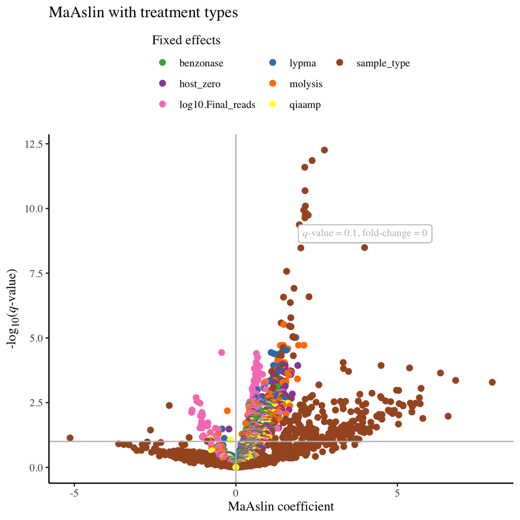

Done.

```r
#===============================================================================
#BTC.LineZero.Footer.1.1.0
#===============================================================================
#R markdown citation generator.
#===============================================================================
#RLB.Dependencies:
#   magrittr, pacman, stringr
#=-=-=-=-=-=-=-=-=-=-=-=-=-=-=-=-=-=-=-=-=-=-=-=-=-=-=-=-=-=-=-=-=-=-=-=-=-=-=-=
#BTC.Dependencies:
#   LineZero.Header
#===============================================================================
#Generates citations for each explicitly loaded library.
#=-=-=-=-=-=-=-=-=-=-=-=-=-=-=-=-=-=-=-=-=-=-=-=-=-=-=-=-=-=-=-=-=-=-=-=-=-=-=-=
str_libraries <- c("r", str_libraries)
for (str_libraries in str_libraries) {
    str_libraries |>
        pacman::p_citation() |>
        print(bibtex = FALSE) |>
        capture.output() %>%
        .[-1:-3] %>% .[. != ""] |>
        stringr::str_squish() |>
        stringr::str_replace("_", "") |>
        cat()
    cat("\n")
}
```

```
## R Core Team (2022). R: A language and environment for statistical computing. R Foundation for Statistical Computing, Vienna, Austria. URL https://www.R-project.org/. We have invested a lot of time and effort in creating R, please cite it when using it for data analysis. See also 'citation("pkgnam…
## Wickham H, Bryan J (2023). readxl: Read Excel Files_. R package version 1.4.2, <https://CRAN.R-project.org/package=readxl>.
## phyloseq: An R package for reproducible interactive analysis and graphics of microbiome census data. Paul J. McMurdie and Susan Holmes (2013) PLoS ONE 8(4):e61217.
## Wickham H, Averick M, Bryan J, Chang W, McGowan LD, François R, Grolemund G, Hayes A, Henry L, Hester J, Kuhn M, Pedersen TL, Miller E, Bache SM, Müller K, Ooms J, Robinson D, Seidel DP, Spinu V, Takahashi K, Vaughan D, Wilke C, Woo K, Yutani H (2019). "Welcome to the tidyverse." Journal of Open …
## Rinker, T. W. & Kurkiewicz, D. (2017). pacman: Package Management for R. version 0.5.0. Buffalo, New York. http://github.com/trinker/pacman
## Garbett SP, Stephens J, Simonov K, Xie Y, Dong Z, Wickham H, Horner J, reikoch, Beasley W, O'Connor B, Warnes GR, Quinn M, Kamvar ZN (2023). yaml: Methods to Convert R Data to YAML and Back_. R package version 2.3.7, <https://CRAN.R-project.org/package=yaml>. ATTENTION: This citation information …
## H. Wickham. ggplot2: Elegant Graphics for Data Analysis. Springer-Verlag New York, 2016.
## Oksanen J, Simpson G, Blanchet F, Kindt R, Legendre P, Minchin P, O'Hara R, Solymos P, Stevens M, Szoecs E, Wagner H, Barbour M, Bedward M, Bolker B, Borcard D, Carvalho G, Chirico M, De Caceres M, Durand S, Evangelista H, FitzJohn R, Friendly M, Furneaux B, Hannigan G, Hill M, Lahti L, McGlinn D…
## Leo Lahti et al. microbiome R package. URL: http://microbiome.github.io
## Kassambara A (2023). ggpubr: 'ggplot2' Based Publication Ready Plots. R package version 0.6.0, <https://CRAN.R-project.org/package=ggpubr>.
## Simon Garnier, Noam Ross, Robert Rudis, Antônio P. Camargo, Marco Sciaini, and Cédric Scherer (2021). Rvision - Colorblind-Friendly Color Maps for R. R package version 0.6.2.
## Davis NM, Proctor D, Holmes SP, Relman DA, Callahan BJ (2017). "Simple statistical identification and removal of contaminant sequences in marker-gene and metagenomics data." bioRxiv_, 221499. doi:10.1101/221499 <https://doi.org/10.1101/221499>.
## Auguie B (2017). gridExtra: Miscellaneous Functions for "Grid" Graphics. R package version 2.3, <https://CRAN.R-project.org/package=gridExtra>.
## Kassambara A (2023). ggpubr: 'ggplot2' Based Publication Ready Plots. R package version 0.6.0, <https://CRAN.R-project.org/package=ggpubr>.
## Douglas Bates, Martin Maechler, Ben Bolker, Steve Walker (2015). Fitting Linear Mixed-Effects Models Using lme4. Journal of Statistical Software, 67(1), 1-48. doi:10.18637/jss.v067.i01.
## Kuznetsova A, Brockhoff PB, Christensen RHB (2017). "lmerTest Package: Tests in Linear Mixed Effects Models." Journal of Statistical Software, *82*(13), 1-26. doi:10.18637/jss.v082.i13 <https://doi.org/10.18637/jss.v082.i13>.
## Ooms J (2023). writexl: Export Data Frames to Excel 'xlsx' Format_. R package version 1.4.2, <https://CRAN.R-project.org/package=writexl>.
## Gonçalves da Silva A (2017). harrietr: Wrangle Phylogenetic Distance Matrices and Other Utilities. R package version 0.2.3, <https://CRAN.R-project.org/package=harrietr>.
## Mallick H et al. (2020). Multivariable Association in Population-scale Meta-omics Studies, http://huttenhower.sph.harvard.edu/maaslin2. To cite the MaAsLin 2 software, please use: Mallick H, Rahnavard A, McIver LJ (2020). MaAsLin 2: Multivariable Association in Population-scale Meta-omics Studies…
## Wilke C, Wiernik B (2022). ggtext: Improved Text Rendering Support for 'ggplot2'. R package version 0.1.2, <https://CRAN.R-project.org/package=ggtext>.
## Aphalo P (2022). ggpmisc: Miscellaneous Extensions to 'ggplot2'_. R package version 0.5.2, <https://CRAN.R-project.org/package=ggpmisc>.
## Auguie B (2017). gridExtra: Miscellaneous Functions for "Grid" Graphics. R package version 2.3, <https://CRAN.R-project.org/package=gridExtra>.
## Wood S, Scheipl F (2020). gamm4: Generalized Additive Mixed Models using 'mgcv' and 'lme4'. R package version 0.2-6, <https://CRAN.R-project.org/package=gamm4>. ATTENTION: This citation information has been auto-generated from the package DESCRIPTION file and may need manual editing, see 'help("c…
## Hadley Wickham (2007). Reshaping Data with the reshape Package. Journal of Statistical Software, 21(12), 1-20. URL http://www.jstatsoft.org/v21/i12/.
## Zhu H (2021). kableExtra: Construct Complex Table with 'kable' and Pipe Syntax. R package version 1.3.4, <https://CRAN.R-project.org/package=kableExtra>.
## Yihui Xie (2023). knitr: A General-Purpose Package for Dynamic Report Generation in R. R package version 1.42. Yihui Xie (2015) Dynamic Documents with R and knitr. 2nd edition. Chapman and Hall/CRC. ISBN 978-1498716963 Yihui Xie (2014) knitr: A Comprehensive Tool for Reproducible Research in R. I…
```

```r
#===============================================================================
```